```python
name = "Diogo José Costa Alves"  # write YOUR NAME

honorPledge = "I affirm that I have not given or received any unauthorized\n"+\
              "help on this assignment, and that this work is my own.\n"


print("\nName: ", name)
print("\nHonor pledge: ", honorPledge)
```

```
Name:  Diogo José Costa Alves

Honor pledge:  I affirm that I have not given or received any unauthorized
help on this assignment, and that this work is my own.
```

# MAC0460 / MAC5832 (2022)

## EP3: Logistic regression

### Topics / concepts explored in this EP:

- Implementation of the **logistic regression algorithm**, using the gradient descent technique
- Application on binary classification of toy datasets
- Effects of parameters, unbalanced classes

### Evaluation criteria

- Correctitude of the algorithms
- Code
  - do not change the prototype of the functions
  - efficiency (you should avoid unnecessary loops; use matrix/vector computation with NumPy wherever appropriate)
  - cleanliness (do not leave any commented code or useless variables)
- Appropriateness of the answers
- File format: Complete and submit this notebook with the outputs of the execution. **Do no change the file name.**  
  Places to be filled are indicated with this color

### Remarks

- In this notebook vectors are implemented as `ndarray (n,)` and not as `ndarray (n,1)`
- It might be wise to first make sure your implementation is correct. For instance, you can compare the results of your implementation with the ones obtained with the implementation available in [scikit-learn](https://scikit-learn.org/stable/).

# The algorithm

We will use the formulation described in the textbook (*Learning from data*, Abu-Mostafa *et al.*).  
Note: Positive class label is equal to +1 and negative class label is equal to -1.

The loss (or cost) function to be minimized is $$ E_{in}(\mathbf{w}) = \frac{1}{N} \sum_{i=1}^{N} \ln(1 + e^{-y^{(i)} \mathbf{w}^T \mathbf{x}^{(i)}}) \tag{1} $$

Its gradient is given by

$$\nabla E_{in}(\mathbf{w}) = - \frac{1}{N}\sum_{i=1}^{N} \frac{y^{(i)} \mathbf{x}^{(i)}}{1 + e^{y^{(i)} \mathbf{w}^T \mathbf{x}^{(i)}}} \tag{2}$$

The logistic (sigmoid) function is $$\sigma(z) = \frac{1}{1 + e^{-z}} \tag{3}$$

```python
# All imports

import numpy as np

import matplotlib.pyplot as plt
from matplotlib.lines import Line2D

from sklearn.datasets import make_blobs

%matplotlib inline

print('Setup complete!!!')
```

```
Setup complete!!!
```

# 1. Training and prediction algorithms

In the next four code cells, write the code to implement the specified functions. These functions should be used afterwards for some training and prediction cases. Use vectorial computation with NumPy.

## 1.1. Cross-entropy loss

This is Equation (1) above.

```python
def cross_entropy_loss(w, X, y):
    """
    Computes the loss (equation 1)
    :param w: weight vector
    :type: np.ndarray(shape=(1+d, ))
    :param X: design matrix
    :type X: np.ndarray(shape=(N, 1+d))
    :param y: class labels
    :type y: np.ndarray(shape=(N, ))
    :return loss: loss (equation 1)
    :rtype: float
    """

    ### ===> Your code begins here
    error = np.log(1 + np.exp( np.multiply(-y, np.dot(X, w)) ) )
    return np.mean(error)
    ### ===> Your code ends here

def cross_entropy_loss_loop(w, X, y):
    sum = 0
    N = X.shape[0]
    for i in range(N):
        x_i = X[i,:]
        y_i = y[i]
        sum += np.log( 1 + np.exp(-y_i * np.dot(x_i, w)))
    average = sum / N
    return average

def test_cross_entropy_loss():
    np.random.seed(0)
    d = 3
    N = 2
    w = np.random.randn(d+1)
    X = np.random.randn(N, d+1)
    y = np.random.randn(N)
    print(f'Shapes w={w.shape} X={X.shape} y={y.shape}')
    result = cross_entropy_loss(w, X, y)
    assert(type(result) == np.float64)
    golden = cross_entropy_loss_loop(w, X, y)
    assert (result == golden)
    print(f'result={result}')

test_cross_entropy_loss()
```

```
Shapes w=(4,) X=(2, 4) y=(2,)
result=0.2880380210690786
```

## 1.2. Gradient of the cross-entropy loss

This is Equation (2) above.

```python
def cross_entropy_gradient(w, X, y):
    """
    Computes the gradient of the loss function (equation 2)
    :param w: weight vector
    :type: np.ndarray(shape=(1+d, ))
    :param X: design matrix
    :type X: np.ndarray(shape=(N, 1+d))
    :param y: class labels
    :type y: np.ndarray(shape=(N, ))
    :return grad: gradient (equation 2)
    :rtype: float
    """

    ### ===> Your code begins here
    N = X.shape[0]
    sum = 0
    for i in range(N):
        x_i = X[i,:]
        y_i = y[i]
        numerator = y_i * x_i
        denominator = 1 + np.exp(y_i * np.dot(x_i, w))
        sum += numerator/denominator
    average = sum / N
    average = sum / N
    return - average
    ### ===> Your code ends here


def test_cross_entropy_gradient():
    np.random.seed(0)
    d = 3
    N = 5
    w = np.random.randn(d+1)
    X = np.random.randn(N, d+1)
    y = np.ones(N)
    print(f'Shapes w={w.shape} X={X.shape} y={y.shape}')
    result = cross_entropy_gradient(w, X, y)
    print(f'result,={result}')
    # assert(result.shape == w.shape) I am a little confused with this exercise gradient calculation. I imagined the it should return something in the same dimension of Weights and not a single float.


test_cross_entropy_gradient()
```

```
Shapes w=(4,) X=(5, 4) y=(5,)
result,=[ 0.40268026 -0.11708381 -0.20214835  0.18187729]
```

## 1.3 Logistic regression training

The function below receives the data matrix `X (shape = (N, d))` and the ouput vector `y (shape = (N,))`, and should return the final weight vector `w (shape = (d+1,))` and, optionally (when parameter `return_history = True`), a list of size `num_iterations+1` with the cross-entropy loss values at the beginning and after each of the iterations.

Note that the data matrix needs to be extended with a column of 1's.

If `w0==None`, then it must be initialized with `w0 = np.random.normal(loc = 0, scale = 1, size = X.shape[1])`

```python
def train_logistic(X, y, learning_rate = 1e-1, w0 = None,\
                        num_iterations = 300, return_history = False):
    """
    Computes the weight vector applying the gradient descent technique
    :param X: design matrix
    :type X: np.ndarray(shape=(N, d))
    :param y: class label
    :type y: np.ndarray(shape=(N, ))
    :return: weight vector
    :rtype: np.ndarray(shape=(1+d, ))
    :return: the history of loss values (optional)
    :rtype: list of float
    """

    ### ===> Your code begins here
    history = []
    X = np.pad(X, (1,0), constant_values=(1,0))[1:,:]
    if w0 == None:
        w0 = np.random.normal(loc = 0, scale = 1, size = X.shape[1])

    w = w0
    history.append( cross_entropy_loss(w, X, y) )

    for i in range(num_iterations):
        gradients = cross_entropy_gradient(w, X, y)
        w = w - learning_rate * gradients
        history.append( cross_entropy_loss(w, X, y) )

    if return_history:
        return w, history
    else:
        return w
    ### ===> Your code ends here

def test_train_logistic():
    d = 3
    N = 10
    np.random.seed(0)
    X = np.random.randn(N, d)
    y = np.ones(N)
    print(f'Shapes X={X.shape} y={y.shape}')

    result, history = train_logistic(X, y, w0=None, num_iterations=300, return_history=True)
    print(f'result={result}')
    print(history)

test_train_logistic()
```

```
Shapes X=(10, 3) y=(10,)
result=[ 2.58457863  1.5382973   0.68505821 -0.23906979]
[1.1701263203355454, 1.1118650977102562, 1.05681482159753, 1.0047802440421667, 0.9555850238190908, 0.9090679850889932, 0.8650799991687442, 0.8234815784783907, 0.7841411532889857, 0.7469339339300504, 0.7117412302233709, 0.6784500951274713, 0.6469531718021734, 0.617148645018669, 0.5889402231266114, 0.…
```

## 1.4. Logistic regression prediction

The function in the next cell will be used to do the prediction. Recall that the prediction is a score in $[0,1]$, given by the sigmoid value of the linear combination.

```python
def sigmoid(z):
    return 1 / (1 + np.exp(-z))


def predict_logistic(X, w):
    """
    Computes the logistic regression prediction
    :param X: design matrix
    :type X: np.ndarray(shape=(N,d))
    :param w: weight vector
    :rtype: np.ndarray(shape=(1+d,))
    :return: predicted classes
    :rtype: np.ndarray(shape=(N,))
    """

    ### ===> Your code begins here
    X = np.pad(X, (1,0), constant_values=(1,0))[1:,:]
    return sigmoid(np.dot(X, w))
    ### ===> Your code ends here

def test_predict_logistic():
    np.random.seed(0)
    d = 3
    N = 10
    w = np.random.randn(d+1)
    X = np.random.randn(N, d)
    result = predict_logistic(X, w)
    print(f'result={result}')

test_predict_logistic()
```

```
result=[0.97549139 0.92570891 0.99296955 0.952343   0.94597013 0.59586403
 0.99845295 0.69155604 0.98467374 0.03253741]
```

# 2. Testing the training and prediction algorithms on toy datasets

## 2.1. 2D data, separable case

### 2.1.1. Generate two blobs of points

```python
# Create two blobs
N = 300
X, y = make_blobs(n_samples=N, centers=2, cluster_std=1, n_features=2, random_state=2)

# change labels 0 to -1
y[y==0] = -1

print("X.shape =", X.shape, "  y.shape =", y.shape)
```

```
X.shape = (300, 2)   y.shape = (300,)
```

### 2.1.2. Let's plot the blobs of points

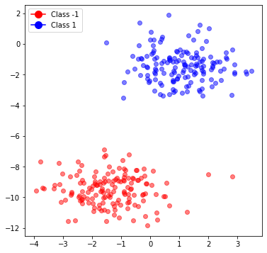

```python
fig = plt.figure(figsize=(6,6))

# plot negatives in red
plt.scatter(X[y==-1,0], \
            X[y==-1,1], \
            alpha = 0.5,\
            c = 'red')

# and positives in blue
plt.scatter(x=X[y==1,0], \
            y=X[y==1,1], \
            alpha = 0.5, \
            c = 'blue')

P=+1
N=-1
legend_elements = [ Line2D([0], [0], marker='o', color='r',\
                    label='Class %d'%N, markerfacecolor='r',\
                    markersize=10),\
                    Line2D([0], [0], marker='o', color='b',\
                    label='Class %d'%P, markerfacecolor='b',\
                    markersize=10) ]

plt.legend(handles=legend_elements, loc='best')
plt.show()
```

### 2.1.3. Let's train the logistic regressor and plot the loss curve

```
completed in 32.953125 seconds

Final weight:
 [9.86538603 1.00043135 1.88684353]

Final loss:
 0.0014283897799052887
```

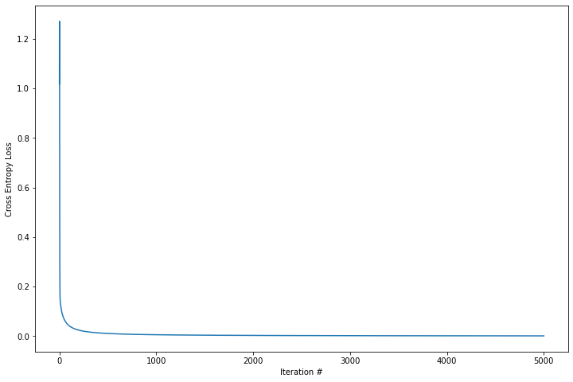

```python
np.random.seed(567)
import time

# ==> Replace the right hand side below with a call to the
# train_logistic() function defined above. Use parameter return_history=True

t = time.process_time()
w_logistic, loss = train_logistic(X, y, w0=None, learning_rate=0.6, num_iterations=5000, return_history=True)
elapsed_time = time.process_time() - t
print(f'completed in {elapsed_time} seconds' )


# ==> Your code insert ends here

print()
print("Final weight:\n", w_logistic)
print()
print("Final loss:\n", loss[-1])

plt.figure(figsize = (12, 8))
plt.plot(loss)
plt.xlabel('Iteration #')
plt.ylabel('Cross Entropy Loss')
plt.show()
```

### 2.1.4. Now, let's plot the decision boundary

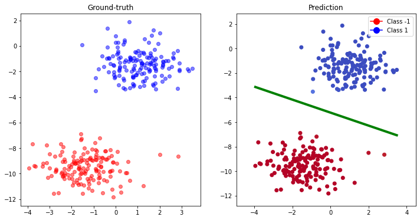

```python
x1min = min(X[:,0])
x1max = max(X[:,0])
x2min = min(X[:,1])
x2max = max(X[:,1])

y_pred = predict_logistic(X, w_logistic)

fig = plt.figure(figsize=(12,6))
ax1 = fig.add_subplot(121)
ax1.set_title("Ground-truth")

# plot negatives in red
ax1.scatter(X[y==-1,0], \
            X[y==-1,1], \
            alpha = 0.5, \
            c = 'red')

# and positives in blue
ax1.scatter(x=X[y==1,0], \
            y=X[y==1,1], \
            alpha = 0.5, \
            c = 'blue')

ax2 = fig.add_subplot(122)

ax2.set_title("Prediction")
ax2.scatter(x = X[:,0], y = X[:,1], c = -y_pred, cmap = 'coolwarm')
ax2.legend(handles=legend_elements, loc='best')
ax2.set_xlim([x1min-1, x1max+1])
ax2.set_ylim([x2min-1, x2max+1])

p1 = (x1min, -(w_logistic[0] + (x1min)*w_logistic[1])/w_logistic[2])
p2 = (x1max, -(w_logistic[0] + (x1max)*w_logistic[1])/w_logistic[2])

lines = ax2.plot([p1[0], p2[0]], [p1[1], p2[1]], '-')
plt.setp(lines, color='g', linewidth=4.0)

plt.show()
```

### 2.1.5. Counting errors

In order to compare properly $y$ and $y_{pred}$ I will convert $y$ domain, from ${-1,+1}$ to ${0, 1}$.

```python
def count_errors(y, y_pred):
    y_remmaped = y.copy()
    y_remmaped[y_remmaped==-1] = 0
    errors = np.count_nonzero( (np.isclose(y_remmaped, y_pred, atol=1e-01)==False) )
    return errors


print(f'Misclassified blobs: {count_errors(y, y_pred)}')
```

```
Misclassified blobs: 0
```

### 2.1.6. Convergence

Try the above training with different number of iterations and learning rates. Comment how did you vary these parameters and what you have observed.

[output not shown]

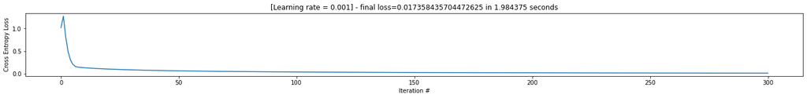

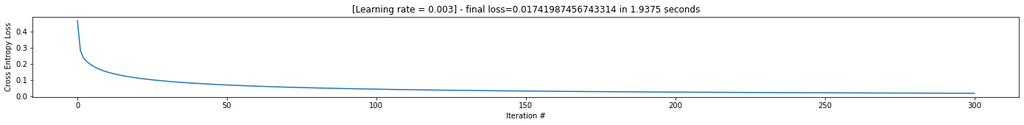

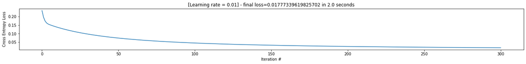

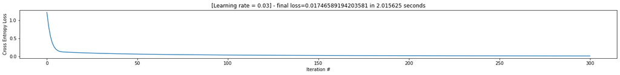

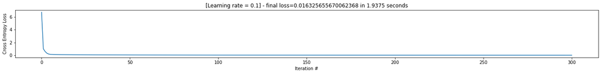

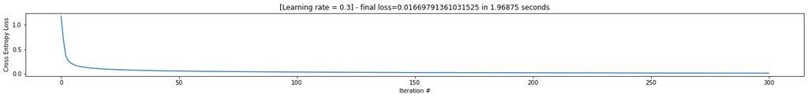

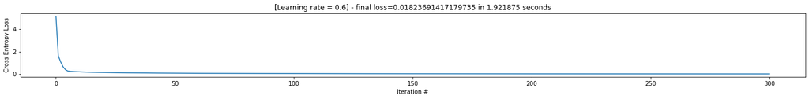

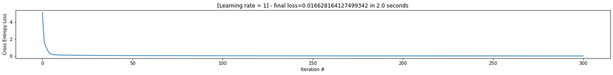

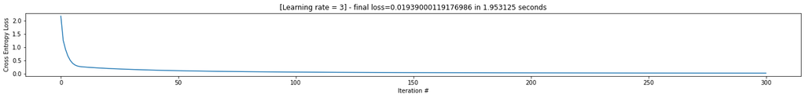

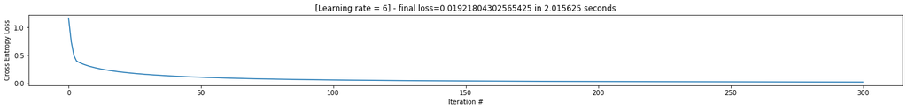

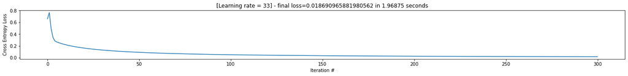

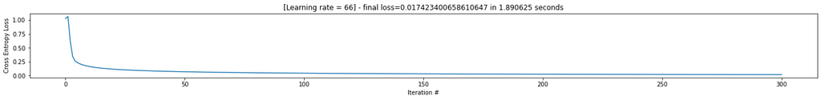

```python
np.random.seed(567)


learning_rates_to_evaluate=[0.001, 0.003, 0.01, 0.03, 0.1, 0.3, 0.6, 1, 3, 6, 33, 66]
# learning_rates_to_evaluate=[0.1]

exploration_results = []

for lr in learning_rates_to_evaluate:
    t = time.process_time()
    w_logistic, loss = train_logistic(X, y, w0=None, learning_rate=0.6, num_iterations=300, return_history=True)
    elapsed_time = time.process_time() - t
    exploration_results.append((loss[-1], elapsed_time, loss) )

    plt.figure(figsize = (24, 2))
    plt.plot(loss)
    plt.title(f'[Learning rate = {lr}] - final loss={loss[-1]} in {elapsed_time} seconds')
    plt.xlabel('Iteration #')
    plt.ylabel('Cross Entropy Loss')
    plt.show()
```

## 2.2. 2D data, overlapping blobs

Repeat 2.1, with overlapping blobs

1. Generate the two classes of points (with cluster overlap) -- see documentation of function `make_blobs()`
2. Plot the points
3. Train the classifier and plot the loss curve
4. Plot the decicion boundary
5. Compute the number of misclassified points

You may just copy and paste the cells of Section 2.1 and make appropriate changes

(Repeating codes is not recommended, but here we do not need to follow it strictly)

```
X.shape = (300, 2)   y.shape = (300,)
```

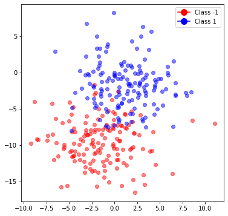

```python
# Create two blobs
N = 300
X, y = make_blobs(n_samples=N, centers=2, cluster_std=3, n_features=2, random_state=2)

# change labels 0 to -1
y[y==0] = -1

print("X.shape =", X.shape, "  y.shape =", y.shape)

fig = plt.figure(figsize=(6,6))

# plot negatives in red
plt.scatter(X[y==-1,0], \
            X[y==-1,1], \
            alpha = 0.5,\
            c = 'red')

# and positives in blue
plt.scatter(x=X[y==1,0], \
            y=X[y==1,1], \
            alpha = 0.5, \
            c = 'blue')

P=+1
N=-1
legend_elements = [ Line2D([0], [0], marker='o', color='r',\
                    label='Class %d'%N, markerfacecolor='r',\
                    markersize=10),\
                    Line2D([0], [0], marker='o', color='b',\
                    label='Class %d'%P, markerfacecolor='b',\
                    markersize=10) ]

plt.legend(handles=legend_elements, loc='best')
plt.show()
```

```
completed in 32.890625 seconds
Final loss=0.206463981379874 | Misclassified blobs: 89 | 32.890625 seconds
```

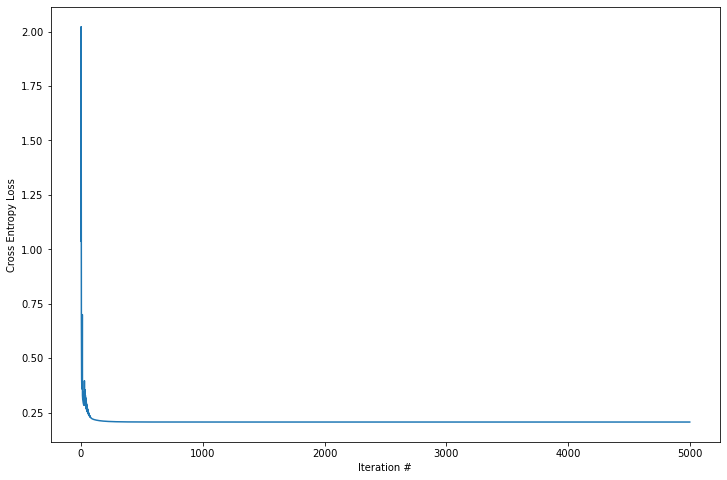

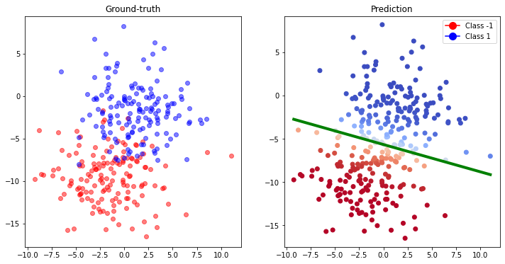

```python
np.random.seed(567)
import time

t = time.process_time()
w_logistic, loss = train_logistic(X, y, w0=None, learning_rate=0.6, num_iterations=5000, return_history=True)
elapsed_time = time.process_time() - t
print(f'completed in {elapsed_time} seconds' )
print(f'Final loss={loss[-1]} | Misclassified blobs: {count_errors(y, y_pred)} | {elapsed_time} seconds')

plt.figure(figsize = (12, 8))
plt.plot(loss)
plt.xlabel('Iteration #')
plt.ylabel('Cross Entropy Loss')
plt.show()

x1min = min(X[:,0])
x1max = max(X[:,0])
x2min = min(X[:,1])
x2max = max(X[:,1])

y_pred = predict_logistic(X, w_logistic)

fig = plt.figure(figsize=(12,6))
ax1 = fig.add_subplot(121)
ax1.set_title("Ground-truth")

# plot negatives in red
ax1.scatter(X[y==-1,0], \
            X[y==-1,1], \
            alpha = 0.5, \
            c = 'red')

# and positives in blue
ax1.scatter(x=X[y==1,0], \
            y=X[y==1,1], \
            alpha = 0.5, \
            c = 'blue')

ax2 = fig.add_subplot(122)

ax2.set_title("Prediction")
ax2.scatter(x = X[:,0], y = X[:,1], c = -y_pred, cmap = 'coolwarm')
ax2.legend(handles=legend_elements, loc='best')
ax2.set_xlim([x1min-1, x1max+1])
ax2.set_ylim([x2min-1, x2max+1])

p1 = (x1min, -(w_logistic[0] + (x1min)*w_logistic[1])/w_logistic[2])
p2 = (x1max, -(w_logistic[0] + (x1max)*w_logistic[1])/w_logistic[2])

lines = ax2.plot([p1[0], p2[0]], [p1[1], p2[1]], '-')
plt.setp(lines, color='g', linewidth=4.0)

plt.show()
```

## 2.3. 2D data with overlapping and unbalanced classes

Repeat 2.2 for unbalanced classes

Repeat the last case (Section 2.2), but now considering a unbalanced class distribution. You may try 80% x 20%, for instance.

```
X.shape = (300, 2)   y.shape = (300,)
```

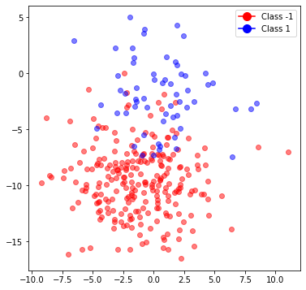

```python
# Create two blobs
N = 300
X, y = make_blobs(n_samples=[240, 60], centers=None, cluster_std=[3,3], n_features=2, random_state=2)

# change labels 0 to -1
y[y==0] = -1

print("X.shape =", X.shape, "  y.shape =", y.shape)

fig = plt.figure(figsize=(6,6))

# plot negatives in red
plt.scatter(X[y==-1,0], \
            X[y==-1,1], \
            alpha = 0.5,\
            c = 'red')

# and positives in blue
plt.scatter(x=X[y==1,0], \
            y=X[y==1,1], \
            alpha = 0.5, \
            c = 'blue')

P=+1
N=-1
legend_elements = [ Line2D([0], [0], marker='o', color='r',\
                    label='Class %d'%N, markerfacecolor='r',\
                    markersize=10),\
                    Line2D([0], [0], marker='o', color='b',\
                    label='Class %d'%P, markerfacecolor='b',\
                    markersize=10) ]

plt.legend(handles=legend_elements, loc='best')
plt.show()
```

```
completed in 32.234375 seconds
Final loss=0.1869628643524899 | Misclassified blobs: 155 | 32.234375 seconds
```

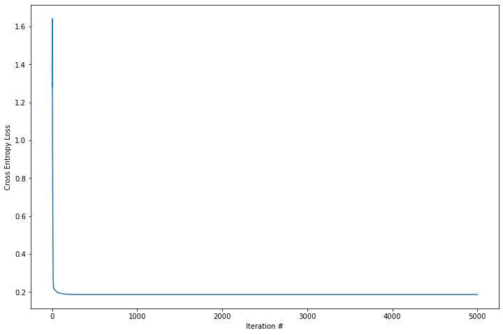

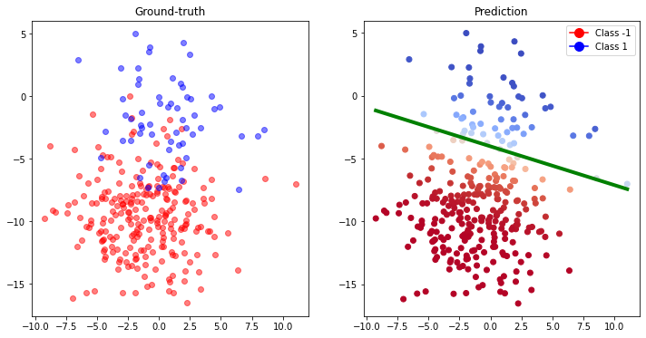

```python
np.random.seed(567)
import time

t = time.process_time()
w_logistic, loss = train_logistic(X, y, w0=None, learning_rate=0.6, num_iterations=5000, return_history=True)
elapsed_time = time.process_time() - t
print(f'completed in {elapsed_time} seconds' )
print(f'Final loss={loss[-1]} | Misclassified blobs: {count_errors(y, y_pred)} | {elapsed_time} seconds')

plt.figure(figsize = (12, 8))
plt.plot(loss)
plt.xlabel('Iteration #')
plt.ylabel('Cross Entropy Loss')
plt.show()

x1min = min(X[:,0])
x1max = max(X[:,0])
x2min = min(X[:,1])
x2max = max(X[:,1])

y_pred = predict_logistic(X, w_logistic)

fig = plt.figure(figsize=(12,6))
ax1 = fig.add_subplot(121)
ax1.set_title("Ground-truth")

# plot negatives in red
ax1.scatter(X[y==-1,0], \
            X[y==-1,1], \
            alpha = 0.5, \
            c = 'red')

# and positives in blue
ax1.scatter(x=X[y==1,0], \
            y=X[y==1,1], \
            alpha = 0.5, \
            c = 'blue')

ax2 = fig.add_subplot(122)

ax2.set_title("Prediction")
ax2.scatter(x = X[:,0], y = X[:,1], c = -y_pred, cmap = 'coolwarm')
ax2.legend(handles=legend_elements, loc='best')
ax2.set_xlim([x1min-1, x1max+1])
ax2.set_ylim([x2min-1, x2max+1])

p1 = (x1min, -(w_logistic[0] + (x1min)*w_logistic[1])/w_logistic[2])
p2 = (x1max, -(w_logistic[0] + (x1max)*w_logistic[1])/w_logistic[2])

lines = ax2.plot([p1[0], p2[0]], [p1[1], p2[1]], '-')
plt.setp(lines, color='g', linewidth=4.0)

plt.show()
```

## 2.4. 3D+ data

This section is to make sure your implementation works for data points with dimension $d>2$.

Write code for blobs that are sufficiently separated and with dimension $d$ at least 3. Compute the number of misclassified points at the end.

You may try larger dimension and also overlapping blobs.

In this sestion, there is no need to plot the blob of points nor the decision boundary (3D plot may be misleading and we are not able to plot data of larger dimension anyway ...)

```python
# Create two blobs
N = 300
X, y = make_blobs(n_samples=N, centers=2, cluster_std=3, n_features=10, random_state=2)

# change labels 0 to -1
y[y==0] = -1

print("X.shape =", X.shape, "  y.shape =", y.shape)
```

```
X.shape = (300, 10)   y.shape = (300,)
```

```
completed in 0.6875 seconds
Final loss=0.0001757351548296016 | Misclassified blobs: 187 | 0.6875 seconds
```

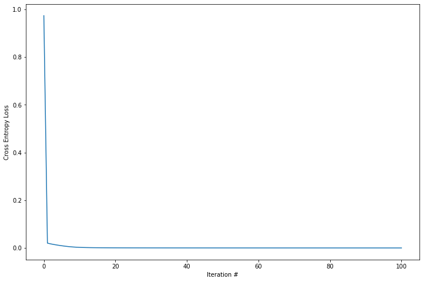

```python
np.random.seed(567)
import time

t = time.process_time()
w_logistic, loss = train_logistic(X, y, w0=None, learning_rate=0.6, num_iterations=100, return_history=True)
elapsed_time = time.process_time() - t
print(f'completed in {elapsed_time} seconds' )
print(f'Final loss={loss[-1]} | Misclassified blobs: {count_errors(y, y_pred)} | {elapsed_time} seconds')

plt.figure(figsize = (12, 8))
plt.plot(loss)
plt.xlabel('Iteration #')
plt.ylabel('Cross Entropy Loss')
plt.show()
```